# Linear/Quadratic Discriminant Analysis

### Sunah Park

This markdown file is created by Sunah Park for extended lab exercises in the book *An Introduction to Statistical Learning with Applications in R* [(ISLR)](https://www-bcf.usc.edu/~gareth/ISL/ISLR%20First%20Printing.pdf).

### Setup for code chunks

```r
rm(list=ls())
# default r markdown global options in document
knitr::opts_chunk$set(
   ########## Text results ##########
    echo=TRUE,
    warning=FALSE, # to preserve warnings in the output
    error=FALSE, # to preserve errors in the output
    message=FALSE, # to preserve messages
    strip.white=TRUE, # to remove the white lines in the beginning or end of a source chunk in the output

    ########## Cache ##########
    cache=TRUE,

    ########## Plots ##########
    fig.path="", # prefix to be used for figure filenames
    fig.width=8,
    fig.height=6,
    dpi=200
)
```

```r
library(MASS)
library(ISLR)
library(ggplot2)
library(corrplot)
```

```r
summary(Smarket) # Stock market data from ISLR library
```

```
##       Year           Lag1                Lag2
##  Min.   :2001   Min.   :-4.922000   Min.   :-4.922000
##  1st Qu.:2002   1st Qu.:-0.639500   1st Qu.:-0.639500
##  Median :2003   Median : 0.039000   Median : 0.039000
##  Mean   :2003   Mean   : 0.003834   Mean   : 0.003919
##  3rd Qu.:2004   3rd Qu.: 0.596750   3rd Qu.: 0.596750
##  Max.   :2005   Max.   : 5.733000   Max.   : 5.733000
##       Lag3                Lag4                Lag5
##  Min.   :-4.922000   Min.   :-4.922000   Min.   :-4.92200
##  1st Qu.:-0.640000   1st Qu.:-0.640000   1st Qu.:-0.64000
##  Median : 0.038500   Median : 0.038500   Median : 0.03850
##  Mean   : 0.001716   Mean   : 0.001636   Mean   : 0.00561
##  3rd Qu.: 0.596750   3rd Qu.: 0.596750   3rd Qu.: 0.59700
##  Max.   : 5.733000   Max.   : 5.733000   Max.   : 5.73300
##      Volume           Today           Direction
##  Min.   :0.3561   Min.   :-4.922000   Down:602
##  1st Qu.:1.2574   1st Qu.:-0.639500   Up  :648
##  Median :1.4229   Median : 0.038500
##  Mean   :1.4783   Mean   : 0.003138
##  3rd Qu.:1.6417   3rd Qu.: 0.596750
##  Max.   :3.1525   Max.   : 5.733000
```

```r
head(Smarket,3)
```

```
##   Year  Lag1   Lag2   Lag3   Lag4   Lag5 Volume  Today Direction
## 1 2001 0.381 -0.192 -2.624 -1.055  5.010 1.1913  0.959        Up
## 2 2001 0.959  0.381 -0.192 -2.624 -1.055 1.2965  1.032        Up
## 3 2001 1.032  0.959  0.381 -0.192 -2.624 1.4112 -0.623      Down
```

```r
Smarket<-na.omit(Smarket)
dim(Smarket)
```

```
## [1] 1250    9
```

```r
names(Smarket) # Lag1 to Lag5: percentage returns for each of the five previous trading days, Volume: number of shares traded on the previous day, Today: percentage return on the date in question, Direction: whether the market was Up or Down on this Date
```

```
## [1] "Year"      "Lag1"      "Lag2"      "Lag3"      "Lag4"      "Lag5"
## [7] "Volume"    "Today"     "Direction"
```

## **Linear Discriminant Analysis**

We perform Linear Discriminant Analysis on the Smarket data using lda() function from the MASS library.

```r
# Data Partition
train<-Smarket$Year<2005 # Boolean vector
Smarket_training<-Smarket[train,]
Smarket_test<-Smarket[!train,]

lda.fit<-lda(Direction~Lag1+Lag2, data=Smarket_training)
lda.fit
```

```
## Call:
## lda(Direction ~ Lag1 + Lag2, data = Smarket_training)
##
## Prior probabilities of groups:
##     Down       Up
## 0.491984 0.508016
##
## Group means:
##             Lag1        Lag2
## Down  0.04279022  0.03389409
## Up   -0.03954635 -0.03132544
##
## Coefficients of linear discriminants:
##             LD1
## Lag1 -0.6420190
## Lag2 -0.5135293
```

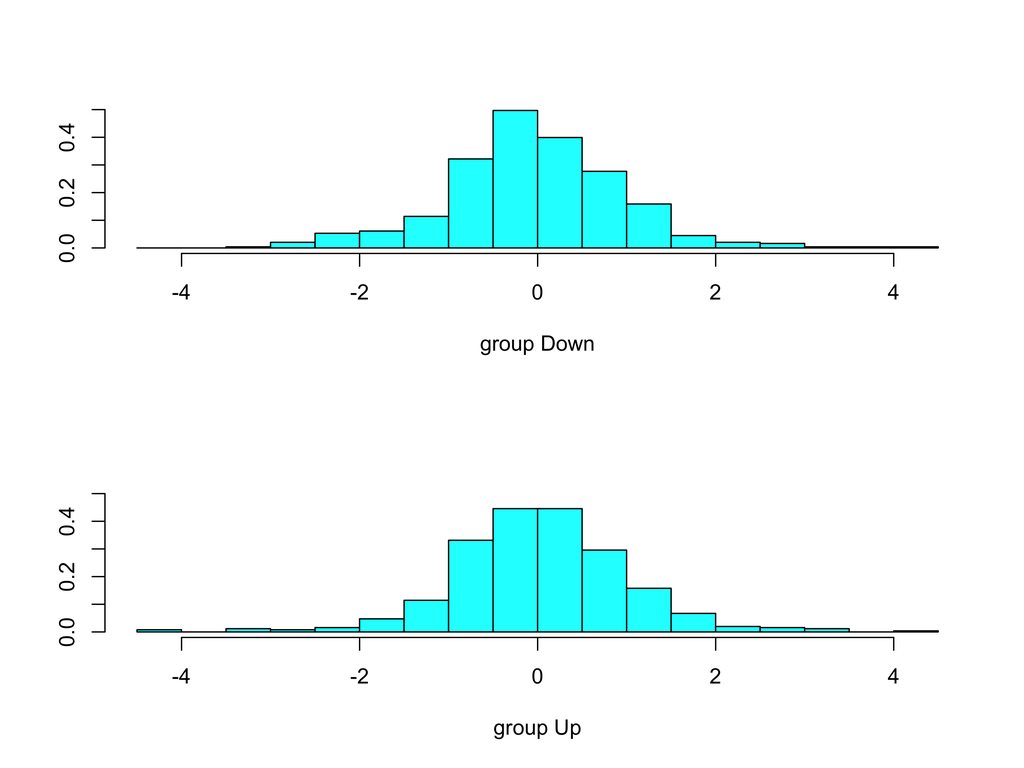

```r
plot(lda.fit)
```

The LDA output indicates that phi1=0.492 and phi2=0.508; in other words, 49.2% of the training observations correspond to days during which the market went down. It also provides the group means; these are the average of each predictor within each class, and are used by LDA as estimates of mu. These suggest that there is a tendency for the previous 2 days’ returns to be negative on days when the market increases, and a tendency for the previous days’ returns to be positive on days when the market declines. The coefficients of linear discriminants output provides the linear combination of Lag1 and Lag2 that are used to form the LDA decision rule:
$$-0.642\times{Lag1}-0.514\times{Lag2}$$
If this value is large, then the LDA classifier will predict a market increase, and if it is small, the LDA classifier will predict a market decline.

```r
lda.pred<-predict(lda.fit, newdata=Smarket_test)
table(lda.pred$class, Smarket_test$Direction)
```

```
##
##        Down  Up
##   Down   35  35
##   Up     76 106
```

```r
mean(lda.pred$class==Smarket_test$Direction)
```

```
## [1] 0.5595238
```

As a result of Linear Discriminant Analysis we achieved the model accuracy of 56%.

## **Quadratic Discriminant Analysis**

We now apply QDA model for the same training data.

```r
qda.fit<-qda(Direction~Lag1+Lag2, data=Smarket_training)
qda.fit
```

```
## Call:
## qda(Direction ~ Lag1 + Lag2, data = Smarket_training)
##
## Prior probabilities of groups:
##     Down       Up
## 0.491984 0.508016
##
## Group means:
##             Lag1        Lag2
## Down  0.04279022  0.03389409
## Up   -0.03954635 -0.03132544
```

The output contains the group means. But it does not contain the coefficients of the linear discriminants, because the QDA classifier involves a quadratic, rather than a linear, function of the predictors.

```r
qda.pred<-predict(qda.fit, newdata=Smarket_test)
table(qda.pred$class, Smarket_test$Direction)
```

```
##
##        Down  Up
##   Down   30  20
##   Up     81 121
```

```r
mean(qda.pred$class==Smarket_test$Direction)
```

```
## [1] 0.5992063
```

Using QDA model, we can predict almost 60% of the time. This suggests that the quadratic form assumed b QDA may capture the true relationship more accurately than the linear forms assumed by LDA and logistic regression.